# HW 9 - MCMC

Shuang Du (PID: 730424618)

# Maximization of poisson GLMM from lecture

Lets now maximize the poisson GLMM model given in lecture, now using an MCEM approach. In a previous HW, you used numerical integration tools to approximate the likelihood for this model, then applied numerical optimization to obtain the estimates of the model parameters.

Here we wish to use MCEM, where in lecture we have already gone over a similar implementation using a rejection sampler in the E-step.

For this HW, please use a Metropolis Hastings Random Walk proposal distribution to approximate the Q-function in the E-step. Specify your proposal distribution. Write functions implementing the E-step, the M-step, and then write the main code for the MCEM algorithm.

Feel free to reuse/modify the lecture code to do this. However, you can implement the M-step and other parts of the EM algorithm however is most convenient to you. Not required by any means, but it may be helpful from a speed perspective to recode the sampler into Rcpp.

```r
## Solution: place relevant helper functions pertaining to the E step here
r.walk = function(){
  rnorm(1,0,0.4)
}

g.sim = function(u){
  u+r.walk()
}

sample.i = function(yi, xi = cbind(rep(1,5), 1:5), M, betat, s2gammat) {
  u = rep(0, M)
  u[1] = rnorm(1, 0, sqrt(s2gammat))
  count = 0
  for (i in 1:(M-1)) {
    u[(i+1)] = g.sim(u[i])
    lambdai = exp(xi %*% betat + u[(i+1)])
    after = sum(dpois(yi, lambda = lambdai, log=T)) + dnorm(u[(i+1)], 0, sqrt(s2gammat), log=T)
    lambdai.1 = exp(xi %*% betat + u[i])
    before = sum(dpois(yi, lambda = lambdai.1, log=T)) + dnorm(u[(i)], 0, sqrt(s2gammat), log=T)
    R = exp(after-before)
    r = min(R,1)
    keep = rbinom(1, 1, r)
    if(keep == 1){
      u[i+1] = u[i+1]
      count = count+1
    }else{
      u[i+1] = u[i]
    }
  }
  return(u)
  print(count/M)
}

sample.all = function(data, M, betat, s2gammat) {
  n = length(unique(data$subject))
  samples = matrix(NA,nrow = n, ncol = M)
  for (i in 1:n) {
    samples.i = sample.i(yi = data$words[data$subject == i], M = M, betat = betat, s2gammat = s2gammat)
    samples[i,] = samples.i
  }
  return(samples)
}
## End Solution

## Solution: place relevant helper functions pertaining to the M step here
Qi = function(datai, xi = cbind(rep(1, 5), 1:5), betat, s2gammat, gammai) {
  yi = datai$words
  M = length(gammai)
  x_beta_mat = xi %*% matrix(betat, nrow = length(betat), ncol = M)
  x_beta_plus_gamma_mat = sweep(x_beta_mat, 2 , gammai, "+")
  lambdai = exp(x_beta_plus_gamma_mat)
  ymat = matrix(yi, nrow = length(yi), ncol = M)
  qi = sum(dpois(ymat, lambda = lambdai, log = T)) + sum(dnorm(gammai, mean = 0,sd = sqrt(s2gammat),log = T))
  qi = qi / M
  return(qi)
}

Q = function(data, betat, s2gammat, samples, logs2gammat = F) {
  if (logs2gammat == T) {
    s2gammat = exp(s2gammat)
  }
  Q = 0
  for (i in 1:22) {
    Q = Q + Qi(data[data$subject == i, ],betat = betat,s2gammat = s2gammat,gammai = samples[i, ])
  }
  return(Q)
}
## End Solution

## Solution: place primary code for the MCEM algorithm here, calling functions in the above two sections
## Remember to print your primary results and use the following starting values, and evaluate chain diagnostics for the final model
# set initial parameters
```

```r
n = length(unique(alz$subject))
tol = 10^-4
maxit = 30
iter = 0
eps = Inf
qfunction = -10000
beta = c(1.816, 0.166)
s2gamma =  0.2192
M = 10000
burn.in = 2000
set.seed(2333)

while(eps > tol & iter < maxit){
  qfunction0 = qfunction
  samples = sample.all(data = alz, M = M, betat = beta, s2gammat = s2gamma)
  qfunction = Q(data = alz, betat = beta, s2gammat = s2gamma, samples = samples)
  eps  = abs(qfunction - qfunction0) / abs(qfunction0)
  fit = optimx(par = c(beta, log(s2gamma)), fn = function(x, data, samples){
      Q(data = alz, betat = x[1:length(beta)], s2gammat = x[length(beta)+1], samples = samples, logs2gammat = T)
    },
    method = "Nelder-Mead",
    data = data,
    samples = samples,
    control = list(trace = 0, maximize = T, abstol= tol))
  beta = as.numeric(fit[1:length(beta)])
  s2gamma = as.numeric(fit[length(beta)+1])
  s2gamma = exp(s2gamma)
  iter = iter + 1
  if(iter == maxit) warning("Iteration limit reached without convergence")
  cat(sprintf("Iter: %d Qf: %.3f s2gamma: %f beta0: %.3f beta0:%.3f eps:%f\n",iter, qfunction,s2gamma, beta[1],beta[2], eps))
}
```

```
## Maximizing -- use negfn and neggr
## Iter: 1 Qf: -268.656 s2gamma: 0.218778 beta0: 1.817 beta0:0.166 eps:0.973134
## Maximizing -- use negfn and neggr
## Iter: 2 Qf: -268.560 s2gamma: 0.219669 beta0: 1.817 beta0:0.166 eps:0.000356
## Maximizing -- use negfn and neggr
## Iter: 3 Qf: -268.630 s2gamma: 0.217576 beta0: 1.817 beta0:0.166 eps:0.000259
## Maximizing -- use negfn and neggr
## Iter: 4 Qf: -268.726 s2gamma: 0.219053 beta0: 1.819 beta0:0.166 eps:0.000359
## Maximizing -- use negfn and neggr
## Iter: 5 Qf: -268.671 s2gamma: 0.218547 beta0: 1.818 beta0:0.166 eps:0.000208
## Maximizing -- use negfn and neggr
## Iter: 6 Qf: -268.759 s2gamma: 0.217844 beta0: 1.817 beta0:0.166 eps:0.000329
## Maximizing -- use negfn and neggr
## Iter: 7 Qf: -268.647 s2gamma: 0.218015 beta0: 1.818 beta0:0.166 eps:0.000417
## Maximizing -- use negfn and neggr
## Iter: 8 Qf: -268.639 s2gamma: 0.220252 beta0: 1.818 beta0:0.166 eps:0.000030
```

```r
## End Solution
```

To evaluate the chain diagnostics for the final model, we present the sample path and histogram for each of the 22 subjects:

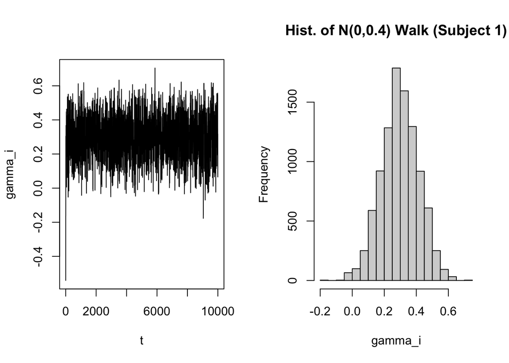

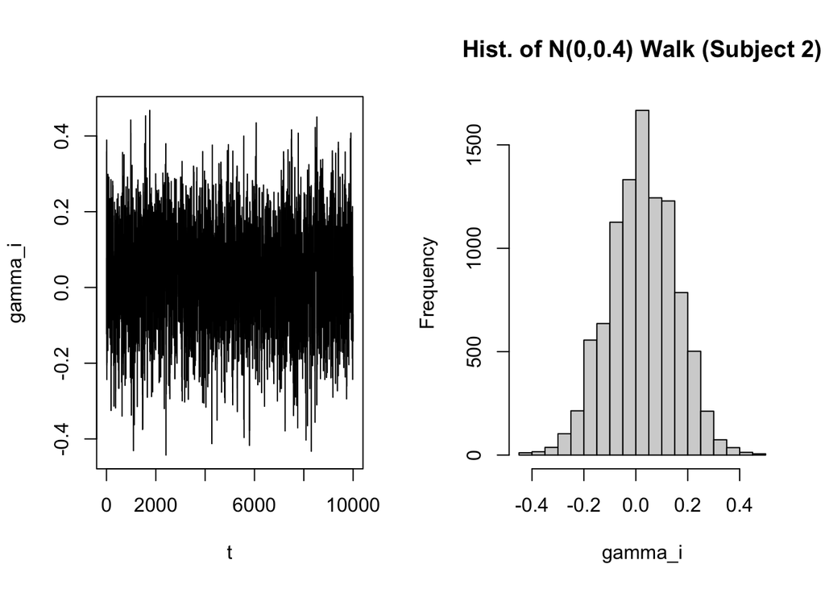

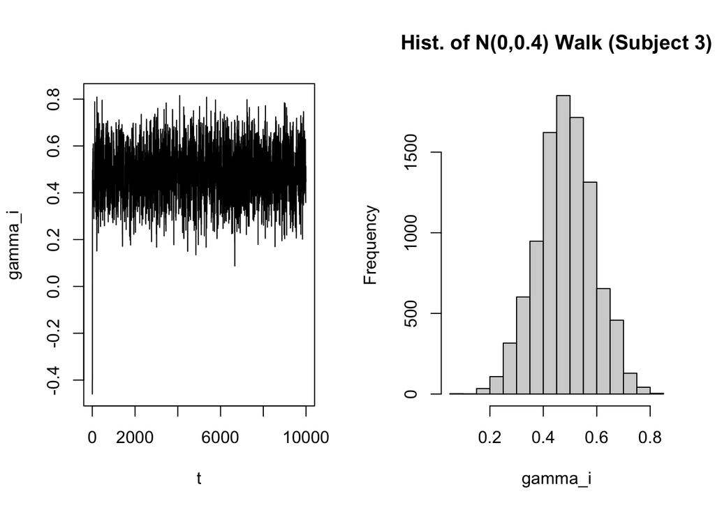

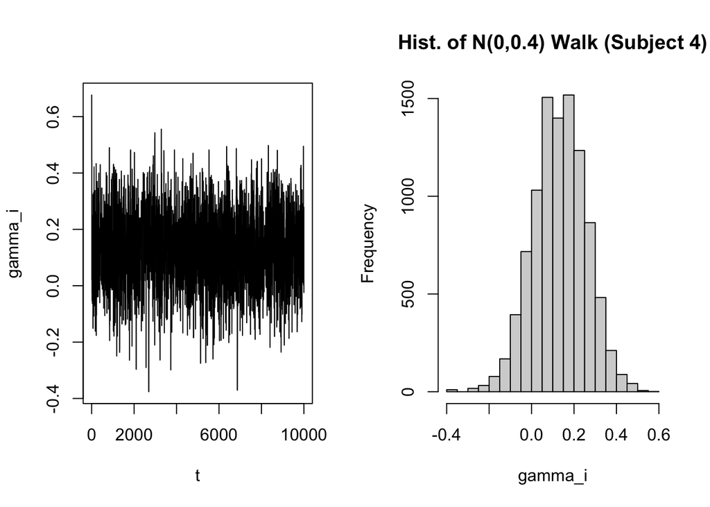

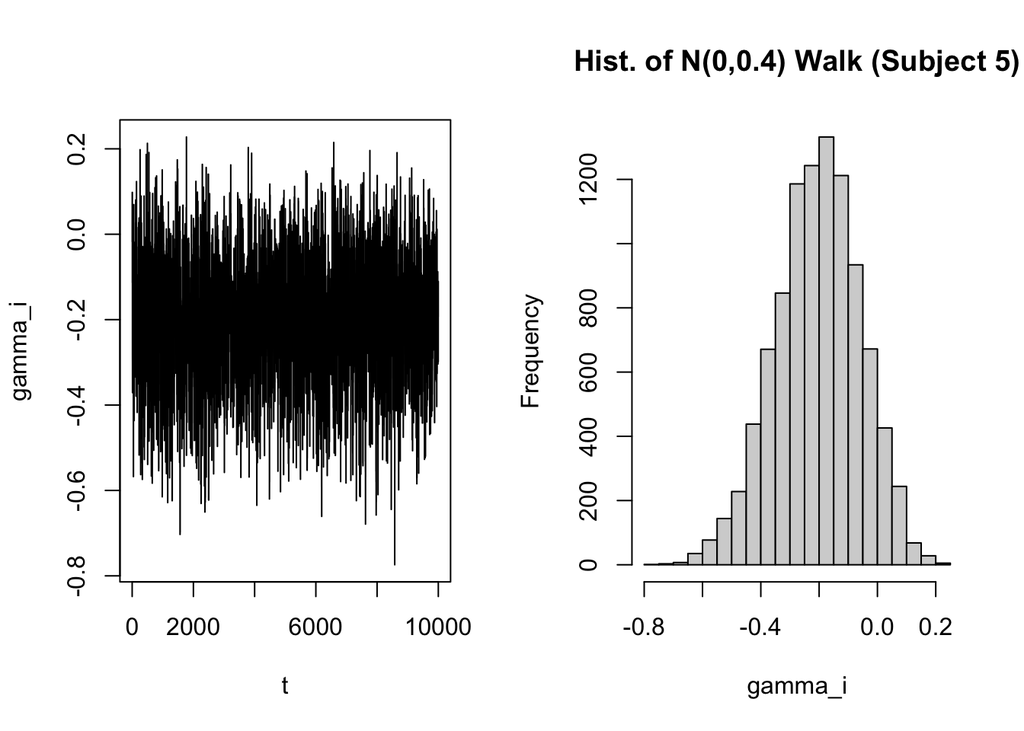

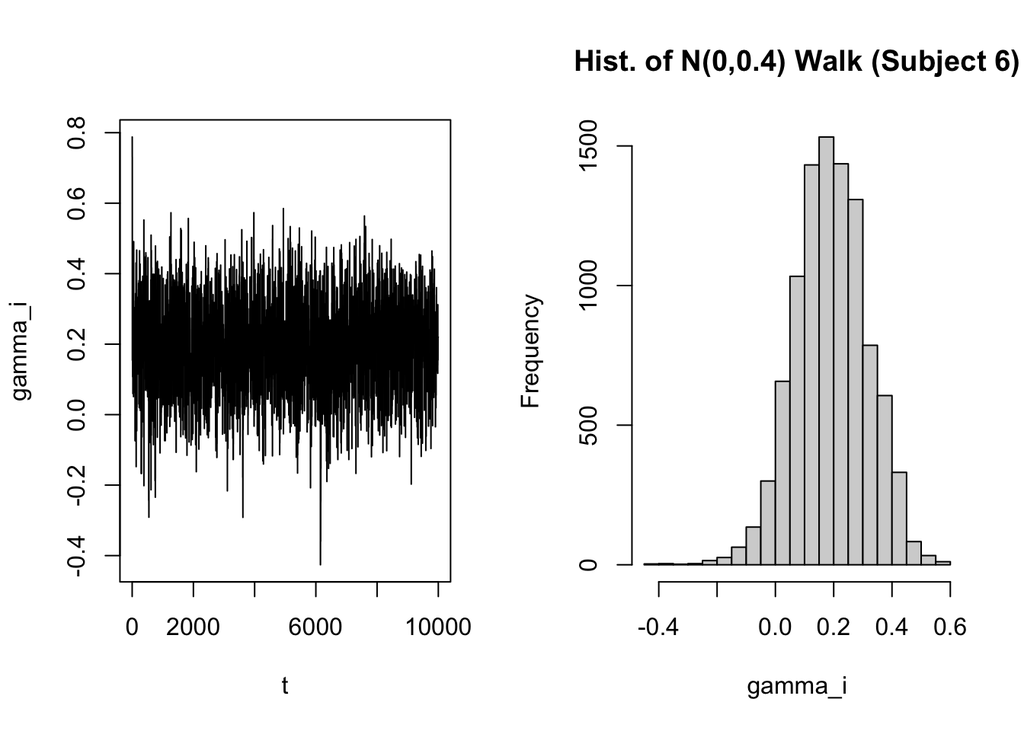

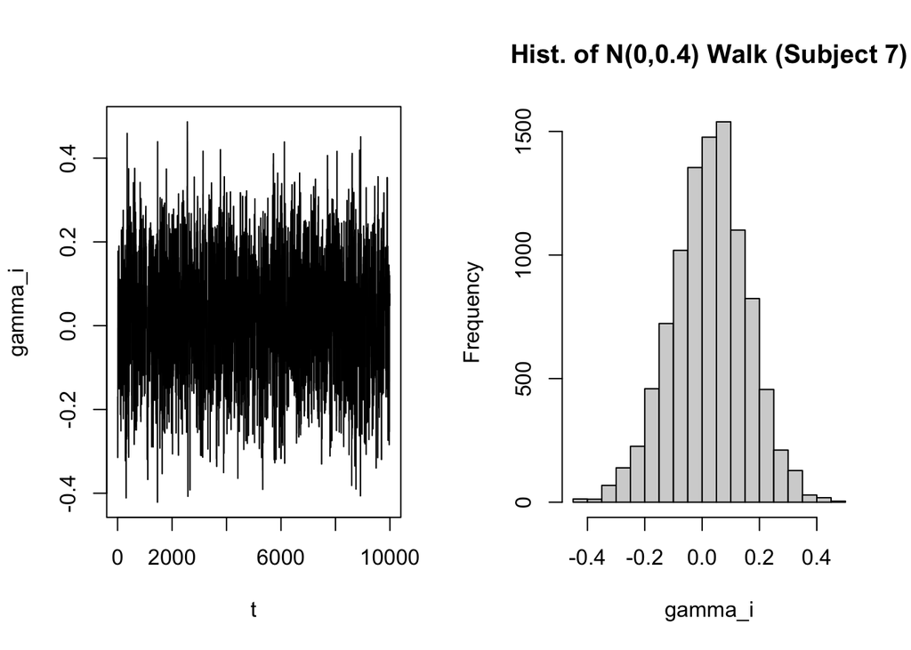

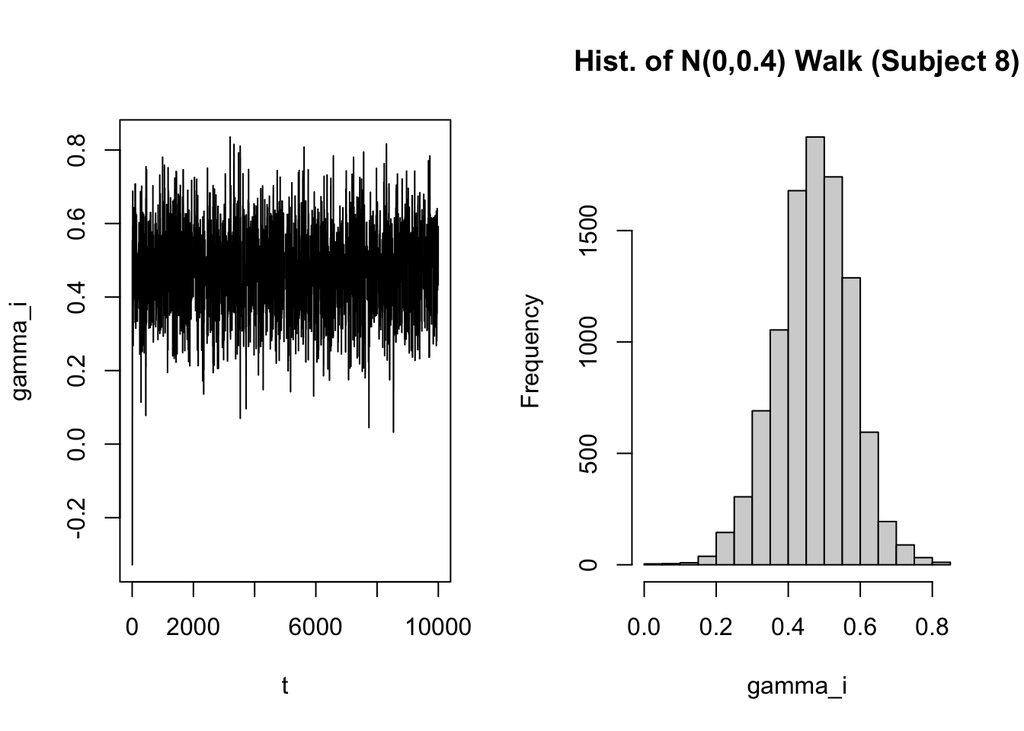

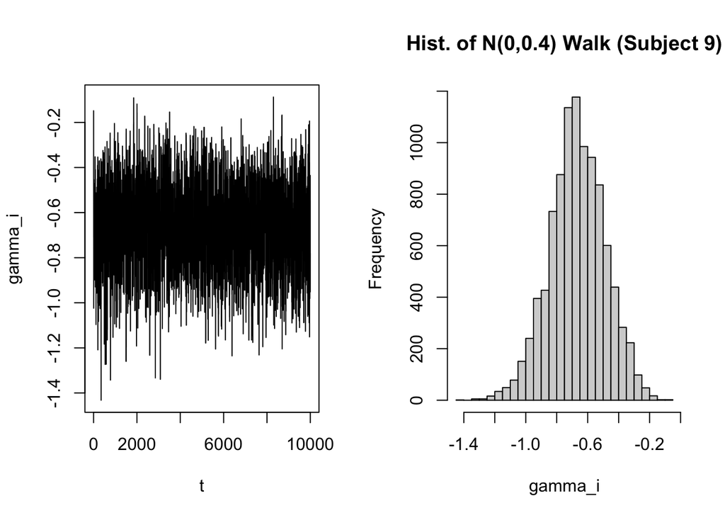

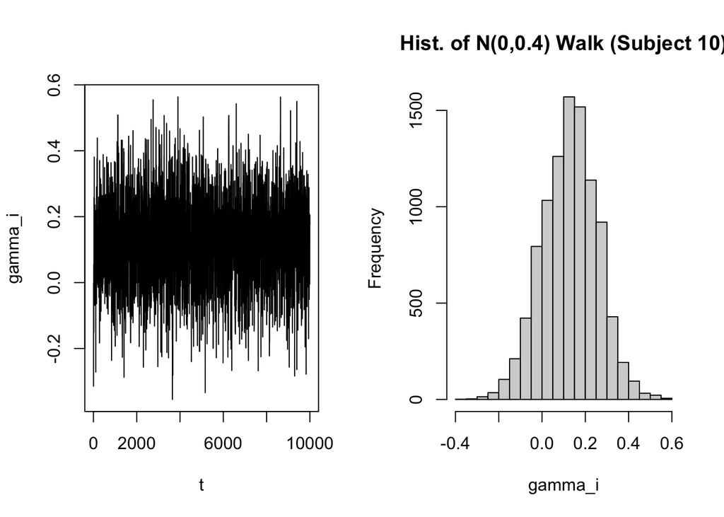

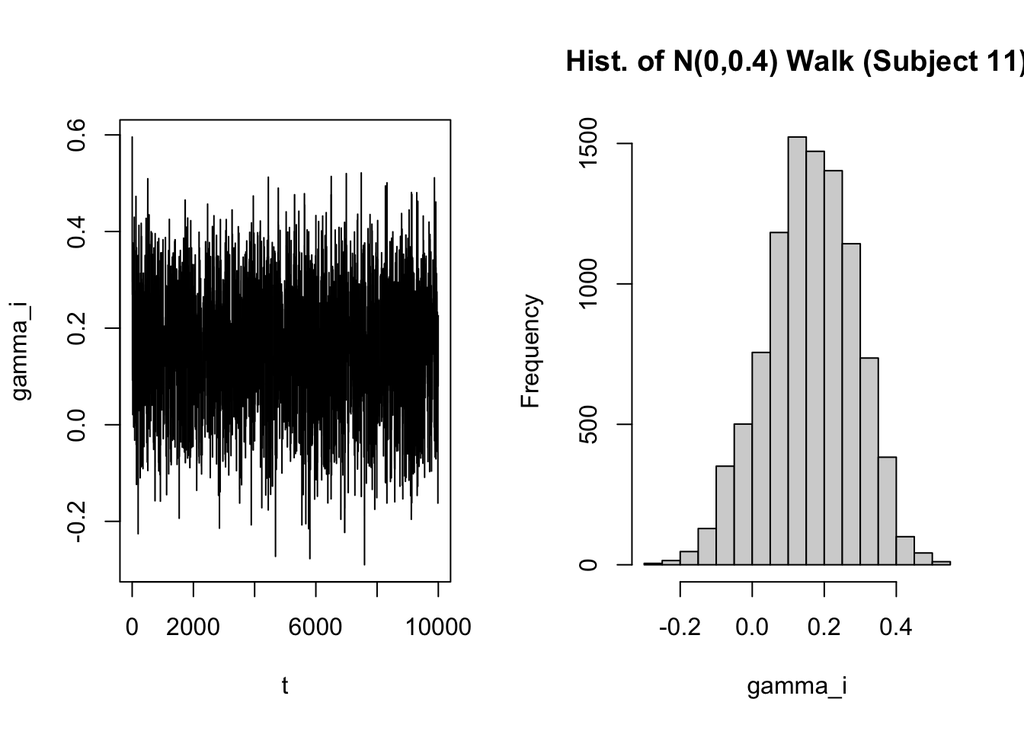

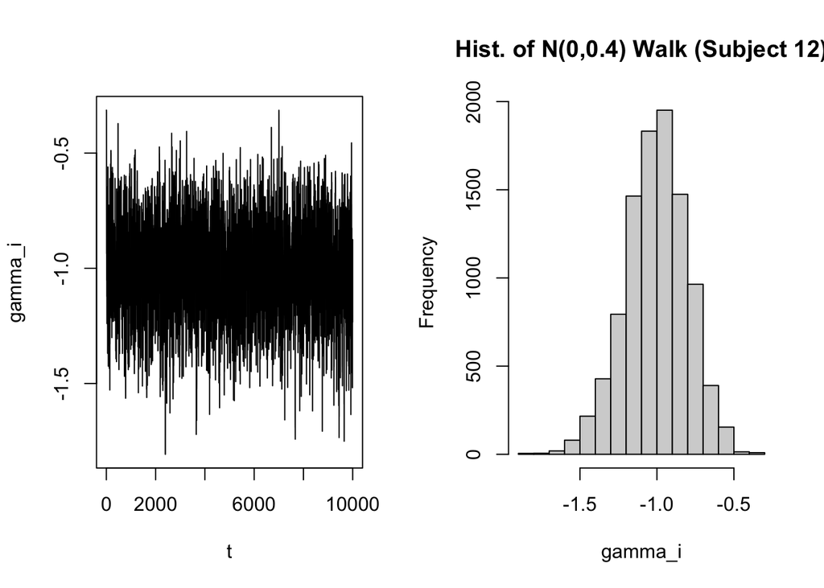

[10 more figures not shown]

```r
for (i in 1:n){
par(mfrow=c(1,2))
# plot sequence
plot(samples[i,],type="l",ylab="gamma_i",xlab="t")
# histogram of values
hist(samples[i, -c(1:200)],breaks=20,xlab="gamma_i",
     main=paste0("Hist. of N(0,0.4) Walk (Subject ", i,")"))
}
```